# Calculating

Currently, there are 8 functions associated with the `calculate` verb in the `sgsR` package:

| Algorithm | Description |
| --- | --- |
| `calculate_representation()` | Determine representation of strata in existing sample unit |
| `calculate_distance()` | Per pixel distance to closest `access` vector |
| `calculate_pcomp()` | Principal components of input `mraster` |
| `calculate_sampsize()` | Estimated sample sizes based on relative standard error |
| `calculate_allocation()` | Proportional / optimal / equal / manual allocation |
| `calculate_coobs()` | Detail how `existing` sample units are distributed among `mraster` |
| `calculate_pop()` | Population level information (PCA / quantile matrix / covariance matrix) of `mraster` |
| `calculate_lhsOpt()` | Determine optimal Latin hypercube sampling parameters including sample size |

## `calculate_representation()`

`calculate_representation()` function allows the users to verify how a stratification is spatially represented in an `existing` sample. Result in tabular and graphical (if `plot = TRUE`) outputs that compare strata coverage frequency and sampling frequency.

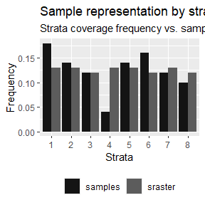

```
#> # A tibble: 8 × 6
#>   strata srasterFreq sampleFreq diffFreq nSamp  need
#>    <dbl>       <dbl>      <dbl>    <dbl> <int> <dbl>
#> 1      1        0.13       0.18   0.05       9    -2
#> 2      2        0.13       0.14   0.0100     7     0
#> 3      3        0.12       0.12   0          6     0
#> 4      4        0.13       0.04  -0.09       2     5
#> 5      5        0.13       0.14   0.0100     7     0
#> 6      6        0.12       0.16   0.04       8    -2
#> 7      7        0.13       0.12  -0.0100     6     1
#> 8      8        0.12       0.1   -0.0200     5     1
```

```r
#--- quantile sraster ---#
quantiles <- strat_quantiles(
  mraster = mraster$zq90,
  nStrata = 8
)

#--- random samples ---#
srs <- sample_srs(
  raster = sraster,
  nSamp = 50
)

#--- calculate representation ---#
calculate_representation(
  sraster = quantiles,
  existing = srs,
  plot = TRUE
)
```

The tabular output presents the frequency of coverage for each strata (`srasterFreq`) (what % of the landscape does the strata cover) and the sampling frequency within each strata (`sampleFreq`) (what % of total `existing` samples are in the strata). The difference (`diffFreq`) between coverage frequency and sampling frequency determines whether the values are over-represented (positive numbers) or under-represented (negative numbers). This value translates to a discrete `need` attribute that defines whether there is a need to add or remove samples to meet the number of samples necessary to be considered representative of the spatial coverage of strata inputted in `sraster`.

Performing the algorithm on a sample set derived using `sample_strat()` exhibits proportional sampling to strata coverage given that samples were allocated proportionally to spatial coverage.

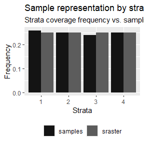

```
#> # A tibble: 4 × 6
#>   strata srasterFreq sampleFreq diffFreq nSamp  need
#>    <dbl>       <dbl>      <dbl>    <dbl> <int> <dbl>
#> 1      1        0.25       0.26   0.0100    51    -1
#> 2      2        0.25       0.25   0         50     0
#> 3      3        0.25       0.24  -0.0100    49     1
#> 4      4        0.25       0.25   0         50     0
```

```r
calculate_representation(
  sraster = sraster,
  existing = existing,
  plot = TRUE
)
```

**TIP!**

Presence of very small (negligible) differences between `srasterFreq` and `sampleFreq` is common. **In these situations, it is important for the user to determine whether to add or remove the samples.**

## `calculate_distance`

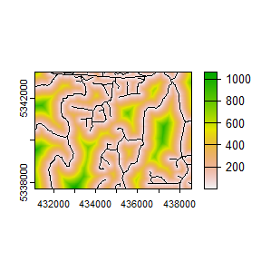

```
#> class       : SpatRaster
#> dimensions  : 277, 373, 2  (nrow, ncol, nlyr)
#> resolution  : 20, 20  (x, y)
#> extent      : 431100, 438560, 5337700, 5343240  (xmin, xmax, ymin, ymax)
#> coord. ref. : UTM Zone 17, Northern Hemisphere
#> source(s)   : memory
#> varnames    : mraster
#>               mraster
#> names       : strata, dist2access
#> min values  :      1,      0.3438
#> max values  :      4,   1061.6599
```

```r
calculate_distance(
  raster = sraster, # input
  access = access, # define access road network
  plot = TRUE
) # plot
|---------|---------|---------|---------|
=========================================
```

*This function performs considerably slower when `access` has many features. Consider mergeing features for improved efficiency.*

## `calculate_pcomp`

`calculate_pcomp()` uses `mraster` as the input and performs principal component analysis. The number of components defined by the `nComp` parameter specifies the number of components that will be rasterized.

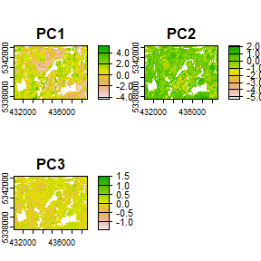

```
#> $pca
#> Standard deviations (1, .., p=3):
#> [1] 1.5479878 0.7359109 0.2493371
#>
#> Rotation (n x k) = (3 x 3):
#>                PC1        PC2        PC3
#> zq90     0.6286296 -0.1795433 -0.7566961
#> pzabove2 0.5104140  0.8293596  0.2272450
#> zsd      0.5867729 -0.5290812  0.6130014
#>
#> $raster
#> class       : SpatRaster
#> dimensions  : 277, 373, 3  (nrow, ncol, nlyr)
#> resolution  : 20, 20  (x, y)
#> extent      : 431100, 438560, 5337700, 5343240  (xmin, xmax, ymin, ymax)
#> coord. ref. : UTM Zone 17, Northern Hemisphere
#> source(s)   : memory
#> varnames    : mraster
#>               mraster
#>               mraster
#> names       :       PC1,       PC2,       PC3
#> min values  : -4.402269, -5.357801, -1.446156
#> max values  :  5.282663,  2.155242,  1.510955
```

```r
calculate_pcomp(
  mraster = mraster, # input
  nComp = 3, # number of components to output
  plot = TRUE, # plot
  details = TRUE
) # details about the principal component analysis appended
```

## `calculate_sampsize`

`calculate_sampsize()` function allows the user to estimate an appropriate sample size using the relative standard error (`rse`) of input metrics. If the input `mraster` contains multiple layers, the sample sizes will be determined for all layers. If `plot = TRUE` and `rse` is defined, a sequence of `rse` values will be visualized with the indicators and the values for the matching sample size.

```r
#--- determine sample size based on relative standard error (rse) of 1% ---#
calculate_sampsize(
  mraster = mraster,
  rse = 0.01
)
```

```
#>   nSamp  rse      var
#> 1  1394 0.01     zq90
#> 2  1341 0.01 pzabove2
#> 3  1859 0.01      zsd
```

```r
#--- change default threshold sequence values ---#
#--- if increment and rse are not divisible the closest value will be taken ---#
p <- calculate_sampsize(
  mraster = mraster,
  rse = 0.025,
  start = 0.01,
  end = 0.08,
  increment = 0.01,
  plot = TRUE
)
```

```
#> 'rse' not perfectly divisible by 'increment'. Selecting closest sample size (rse = 0.03) based on values.
```

```r
p
```

```
#> $nSamp
#> # A tibble: 3 × 3
#> # Groups:   var [3]
#>   nSamp   rse var
#>   <dbl> <dbl> <chr>
#> 1   157  0.03 zq90
#> 2   151  0.03 pzabove2
#> 3   211  0.03 zsd
#>
#> $plot
```

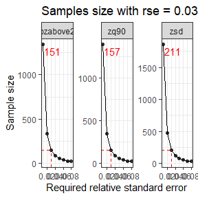

## `calculate_allocation`

`calculate_allocation()` determines how sample units are allocated based on the desired sample size (`nSamp`) and the input `sraster`. It is used internally in a number of algorithms, including `sample_strat`. Currently, there are four allocation methods: proportional (`prop`; default), optimal (`optim`), equal (`equal`), and manual (`manual`).

### Proportional allocation

Samples are allocated based on the spatial coverage area of the strata. This is the default allocation method.

```r
#--- perform grid sampling ---#
calculate_allocation(
  sraster = sraster,
  nSamp = 200
)
```

```
#>   strata total
#> 1      1    51
#> 2      2    50
#> 3      3    49
#> 4      4    50
```

```r
#--- calculate existing samples to include ---#
e.sr <- extract_strata(
  sraster = sraster,
  existing = existing
)

calculate_allocation(
  sraster = sraster,
  nSamp = 200,
  existing = e.sr
)
```

```
#>   strata total need
#> 1      1     0   51
#> 2      2     0   50
#> 3      3     0   49
#> 4      4     0   50
```

At times, values under `total` can be negative. Negative values indicate that `existing` sample units over represent those strata and that some sample units could removed to prevent over-representation. `$total` indicates the number of sample units that could be added or removed.

### Optimal Allocation

Sample units are allocated based on within strata variance. The optimal allocation method uses the variation within the strata metric to allocate sample units. This means that in addition to providing an `sraster`, that a specific metric (`mraster`) must be provided to calculate variation to optimally allocate sample units.

```r
calculate_allocation(
  sraster = sraster, # stratified raster
  nSamp = 200, # desired sample number
  existing = e.sr, # existing samples
  allocation = "optim", # optimal allocation
  mraster = mraster$zq90, # metric raster
  force = TRUE
) # force nSamp number
```

```
#> # A tibble: 4 × 3
#> # Rowwise:
#>   strata total  need
#>    <dbl> <dbl> <dbl>
#> 1      1    27    78
#> 2      2   -14    36
#> 3      3   -25    24
#> 4      4    12    62
```

### Equal allocation

There may be situations where the user wants an equal number of sample units allocated to each strata. In these situations use `allocation = equal`. In this case, `nSamp` refers to the total number of sample units per strata, instead of the overall total number.

```r
calculate_allocation(
  sraster = sraster, # stratified raster
  nSamp = 20, # desired sample number
  allocation = "equal"
) # optimal allocation
```

```
#> Implementing equal allocation of samples.
#> # A tibble: 4 × 2
#>   strata total
#>    <dbl> <dbl>
#> 1      1    20
#> 2      2    20
#> 3      3    20
#> 4      4    20
```

The code in the demonstration above yields a total of 80 samples (20 `nSamp` for each of the 4 strata in `sraster`).

### Manual allocation

The user may wish to manually assign weights to strata. In this case, `allocation = manual` can be used and `weights` must be provided as a numeric vector (e.g. `weights = c(0.2, 0.2, 0.2, 0.4)` where `sum(weights) == 1`). In this case, `nSamp` will be allocated based on `weights`.

```r
weights <- c(0.2, 0.2, 0.2, 0.4)

calculate_allocation(
  sraster = sraster, # stratified raster
  nSamp = 20, # desired sample number
  allocation = "manual", # manual allocation
  weights = weights
) # weights adding to 1
```

```
#> Implementing allocation of samples based on user-defined weights.
#>   strata total
#> 1      1     4
#> 2      2     4
#> 3      3     4
#> 4      4     8
```

The code above yields a total of 20 sample units with plots being allocated based on the `weights` provided in ascending strata order.

## Sample evaluation algorithms

The following algorithms were initially developed by Dr. Brendan Malone from the University of Sydney. Dr. Malone and his colleagues supplied an in depth description of the functionality of these algorithms, which were originally developed to improve soil sampling strategies. These functions were modified and implemented to be used for structurally guided sampling approaches. Many thanks to Dr. Malone for being a proponent of open source algorithms.

Please consult the original reference for these scripts and ideas as their publication holds helpful and valuable information to understand their rationale for sampling and algorithm development.

*Malone BP, Minansy B, Brungard C. 2019. Some methods to improve the utility of conditioned Latin hypercube sampling. PeerJ 7:e6451 DOI 10.7717/peerj.6451*

### `calculate_coobs`

`calculate_coobs()` function performs the **CO**unt of **OBS**ervations (coobs) algorithm using an `existing` sample and `mraster`. This algorithm helps the user understand how an `existing` sample is distributed among the landscape in relation to `mraster` data.

**TIP!**

The output coobs raster can be used to constrain clhs sampling using the `sample_clhs()` function to the areas that are under-represented.

The coobs raster determines how many observations are similar in terms of the covariate space at every pixel, and takes advantage of parallel processing routines.

```r
calculate_coobs(
  mraster = mraster, # input
  existing = existing, # existing samples
  cores = 4, # parallel cores to use
  details = TRUE, # provide details from algorithm output
  plot = TRUE
) # plot
```

## Latin hypercube sampling evaluation algorithms

The following 2 algorithms present the means to maximize the effectiveness of the latin hypercube sampling protocols.

### `calculate_pop`

`calculate_pop()` calculates population level statistics of an `mraster`, including calculating the principal components, quantile & covariate distributions, and Kullback-Leibler divergence testing.

The outputs produced from this functions are required to use the `calculate_lhsOpt()` function described in the following section.

**TIP!**

This algorithm can be pre-emptively used to calculate `matQ` and `MatCov`, two values that are used for the `sample_ahels()` function. This will save processing time during sampling.

```r
#--- by default all statistical data are calculated ---#
calculate_pop(mraster = mraster) # input
```

The output list contains the following:

- `$values` - Pixel values from `mraster`
- `$pcaLoad` - PCA loadings
- `$matQ` - Quantile matrix
- `$matCov` - Covariate matrix

```r
#--- statistical analyses can be chosen by setting their parameter to `FALSE` ---#
mat <- calculate_pop(
  mraster = mraster, # input
  nQuant = 10
) # desired number of quantiles

#--- use matrix output within sample ahels algorithm ---#
sample_ahels(
  mraster = mraster, # input
  existing = existing, # existing sample
  nQuant = 10, # number of desired quantiles
  nSamp = 50, # desired sample size
  matCov = mat
) # covariance matrix
```

### `calculate_lhsOpt`

`calculate_lhsOpt()` function performs a bootstrapped latin hypercube sampling approach where population level analysis of `mraster` data is performed to determine the optimal latin hypercube sample size.

```r
#--- calculate lhsPop details ---#
poplhs <- calculate_pop(mraster = mr)

calculate_lhsOpt(popLHS = poplhs)
```

```r
calculate_lhsOpt(
  popLHS = poplhs,
  PCA = FALSE,
  iter = 200
)
```